# Changes in mortality and child survival for mothers

Ivan Williams and Diego Alburez-Gutierrez

07 August 2019

## Abstract

### Background

The expected number of descendants for mothers is an important relation in kinship theory. Child survival (and child death) affect mothers in a variety of ways, yet it is not clear how changes in mortality schedules, given a fertility pattern, affect the number of surviving children from the standpoint of mothers.

### Objective

Existing formal demographic tools are used within a stable population framework to characterize child survival from the point of view of a mother, considering both absolute and relative changes in mortality patterns.

### Results

The expected change in child survival given an absolute change in mortality depends on the difference between the age of a mother and the age structure of her surviving children. The effects of relative changes in mortality are explained using a fertility-weighted measure of entropy.

### Contribution

The paper proposes new expresions to characterize the effects of changes in mortality on child survival. The different meassures it introduces can be applied to populations at different stages of the demographic transition.

## 1. Relationship

$CS_a$ is the expected number of surviving children to a woman aged $a$ in a stable female population with fertility rates $m_{x}$ and force of mortality $\mu_{x}$, as proposed by Goodman, Keyfitz, and Pullum (1974):

$$\begin{equation}
\label{eq:CS}
CS_a = \int_{\alpha}^a{m_{x}l_{a-x}dx}.
\end{equation}$$

We now consider the consequences of a change $\delta$ in mortality in the range $[0,a-\alpha]$, where $\alpha$ is the start age of fertility risk.

A discrete approximate of the effect on $CS_a$ given an absolute change in mortality $m_{x,\delta}=m_{x}+\delta$ is:

$$\begin{equation}
\label{eq:abs_change}
\frac{\Delta CS_{a}}{CS_{a}} \approx -(a - \overline{x}_{(CS)}) \Delta\delta.
\end{equation}$$

The relationship is less clear for proportional changes in mortality $m_{x,\delta}=m_{x}(1+\delta)$ given the interaction of birth and mortality rates (Keyfitz and Caswell (2005)). Neverthless we can say that, in discrete terms:

$$\begin{equation}
\label{eq:relat_change}
\frac{\Delta CS_{a}}{CS_{a}} \approx -H_{CS_a} \Delta\delta.
\end{equation}$$

Where $H_{CS_a}$ can be interpreted as a temporary entropy constant until age $a-\alpha$ . Depending the age structure of the survival daughters $C_{CS_a}(x)=\frac{m_{x}l_{a-x}}{CS_{a}}$, is the way that is taken each age contribution to the disparity measure $H_{CS_a}=\int_\alpha^a{C_{CS_a}(x)H(x)}$ (Aburto et al. (2019)).

The effect of a relative change $\delta$ will be bigger when the mortality is more disperse in ages where the fertility is very concentrated.

```
#> [1] 3.502
```

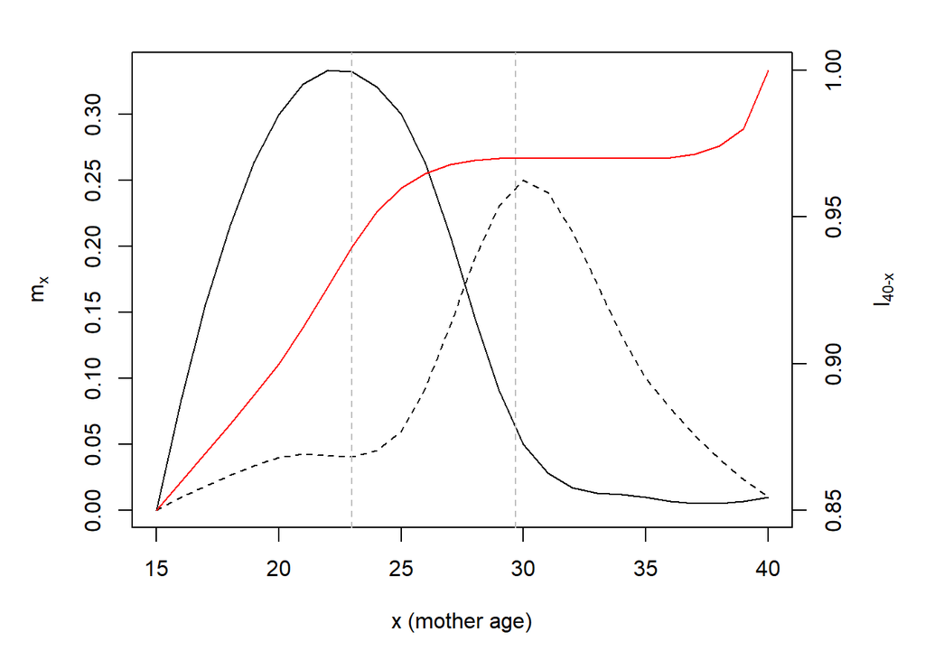

## 2. Proofs

### 2.1. Absolute change

Considering that $m_{x,\delta}=m_{x}+\delta$ ((Wrycza and Baudisch (2012))), and $l_{a-x} = e^{-\int_{0}^{a-x}{(\mu_t+\delta})}$ :

$$\begin{equation}
CS_{(a)}^\delta = \int_{\alpha}^{a}m_{x} l_{a-x} e^{-\delta (a-x)} dx.
\end{equation}$$

To find the effects on daughter survival of adding $\delta$ to the age-specific death rates of daughters, we get the derivative of $dCS_{(a)}^\delta / d\delta$, evaluated near zero (Keyfitz and Caswell (2005), section 4.3):

$$\begin{equation}
\label{eq2}
= -a\int_{\alpha}^{a}m_{x} l_{a-x} dx + \int_{\alpha}^{a}m_{x} l_{a-x}x dx.
\end{equation}$$

Since $CS_{a} = \int_{\alpha}^{a}m_{x} l_{a-x} dx$, we can rewrite equation () as

$$\begin{equation}
\frac{dCS^\delta}{d\delta} = -a CS_{a} + \int_{\alpha}^{a} x m_{x} l_{a-x} dx.
\end{equation}$$

Dividing both sides by $CS_{a}$ and multiplying by $d\delta$, we get

$$\begin{equation}
\label{mort_cont}
\frac{d CS_{a}}{CS_{a}} = -(a - \overline{x}_{(CS)}) d\delta
\end{equation}$$

where $\overline{x}_{(CS)}$ is the mean age of women at the birth of their surviving daughters in a stationary population.

### 2.2. Relative change

Considering that $m_{x,\delta}=m_{x}(1+\delta)$ and $l_{a-x,\delta} = e^{-\int_{0}^{a-x}{\mu_t(1+\delta})dt}=l_{a-x}^{(1+\delta)}$:

$$\begin{equation}
CS_{a}^\delta = \int_{\alpha}^{a} {m_{x} l_{a-x}^{(1+\delta)}} dx.
\end{equation}$$

Using the derivative of $dCS_{(a)}^\delta / d\delta = log(l_{a-x}) l_{a-x}^{(1+\delta)}$ and evaluating $\delta$ near zero we get the final expression:

$$\begin{equation}
\label{mort_change_relative}
\frac{d CS_{a}}{CS_{a}} = \frac{ \int_{\alpha}^{a}m_{x} l_{a-x} \log(l_{a-x}) dx}{CS_{a}} d\delta
\end{equation}$$

Calling $C_{CS_a}(x)=\frac{m_{x}l_{a-x}}{CS_{a}}$ the weighting function of the succesful fertility pattern (onset distribution of survival daughters), and making an analogy with the classical entropy function $H$ where the weights are just the survival function (Keyfitz and Caswell (2005)), we can define this information function $H_{CS_a}=\int_\alpha^a{C_{CS_a}H(x)}$, and get:

$$\begin{equation}
\label{eq:relat_change2}
\frac{dCS_{a}}{CS_{a}} = -H_{CS_a} d\delta.
\end{equation}$$

## 3. History

Kin count estimation has a long pedigree in mathematical demography. Lotka (1931) proposed to model the orphanhood in a theorical population, comparing the effect across demographic regimes. Equation was originally proposed by Brass (1953) to estimate child mortality. The notion of estimating the expected number of living daughters in a stable population was generalized by Goodman, Keyfitz, and Pullum (1974) for other kin relations (granddaughters, cousins, etc.). The “counting method” approach, being the net reproduction rate $R_0$ limited to $a$, or the (not complete) ratio between generations (multiplying and dividing by the mother generation $B$), was further popularized by Keyfitz and Caswell (2005). Bongaarts (1987) used a similar approach to estimate descendants in his ‘Family Status Model’. More recently, Wrycza and Baudisch (2012) has looked at the formal effect of different kind of changes in mortality by age in a paper published in this series.

## 4. Related meassures

### 4.1. Time with children lost

This section proposes three additional measures related to the child survival measure for a mother aged $a$.

*Mean Time Spent with Lost* ($MTSL$) is an absolute measure of the expected time with a death daughter that lives a mother, which can be expressed in terms of a temporary expected lost years measure $e^\dagger$:

$$\begin{equation}
\label{eq:MTSL}
MTSL_a = \int_\alpha^a{m_x\int_0^{a-x}{d_t e_{0,a-x-t} dt}dx} = \int_\alpha^a{m_x e_{o,a-x}^\dagger dx}.
\end{equation}$$

Where $d_t$ is the death distribution from birth, and $e_{0,a-x-t}$ is the life expectancy at birth until age $a-x-t$.

It is reasonable to think that mothers relates these lost years with the expected time with live daughters, getting the *intensity* of her losts (*Intensity Time Lost* ($ITL$)). This makes possible also to compare between fertility regimes:

$$\begin{equation}
\label{eq:ITL}
ITL_a = \frac{\int_\alpha^a{m_x e_{o,a-x}^\dagger dx}}{\int_\alpha^a{m_x e_{o,a-x} dx}}
\end{equation}$$

### 4.2. Mean Age at Child Loss

Different populations could have different mean age at lost ($MAL$) of mothers with death child:

$$\begin{equation}
\label{eq:MAL}
MAL_a = K_a + \int_\alpha^a{f_{x,a} MAD_{a-x}}
\end{equation}$$

$K_a$ is the mean age at birth for womens aged $a$, $MAD_{a-x}$ refers to the mean age at death for those newborns who dies before $a-x$, $TFR_a$ is the cumulated fertility for a women aged a, and $f_{x,a}$ is the cumulative distribution of fertility until age $a$.

Equation can be derived by starting with the integral of the age $x+t$ at each death child weighted by fertility and survival function:

$$\begin{equation}
\label{eq:MALproof}
\begin{split}
MAL_a = \frac{\int_\alpha^a{m_x {\int_0^{a-x}\frac{d_t (x+t) dt}{\int_0^{a-x}{d_tdt}}}}}{\int_\alpha^a{m_x}} \\
MAL_a = \frac{\int_\alpha^a{m_x x}}{TFR_a} + \frac{\int_\alpha^a{m_x MAD_{a-x}}}{TFR_a} \\
MAL_a = K_a + \frac{\int_\alpha^a{m_x MAD_{a-x}}}{TFR_a} \\
MAL_a = K_a + \int_\alpha^a{f_{x,a} MAD_{a-x}}
\end{split}
\end{equation}$$

## 5. Applications

- The proposed meassures are applied to two different demographic regimes.

- A computation approach is used to evaluate the relative contribution of each component given a relative change in $\delta$.

## 5. Bibliography

Aburto, José Manuel, Jesús-Adrián Alvarez, Francisco Villavicencio, and James W. Vaupel. 2019. “The threshold age of the lifetable entropy.” *Demographic Research* 41 (4): 83–102. doi:10.4054/DemRes.2019.41.40.

Bongaarts, John. 1987. “The Projection of Family Composition over the Life Course with Family Status Life Tables.” In *Family Demography: Methods and Their Application*, edited by John Bongaarts and Thomas Burch. Oxford: IUSSP Series, Oxford Univer- sity Pres.

Brass, W. 1953. “The Derivation of Fertility and Reproduction Rates from Restricted Data on Reproductive Histories.” *Population Studies* 7 (2): 137. doi:10.2307/2172029.

Goodman, Leo A, Nathan Keyfitz, and Thomas W Pullum. 1974. “Family Formation and the Frequency of Various Kinship Relationships.” *Theoretical Population Biology* 5 (1). Elsevier: 1–27.

Keyfitz, Nathan, and Hal Caswell. 2005. *Applied Mathematical Demography*. Vol. 47. Springer.

Lotka, Alfred J. 1931. “Orphanhood in Relation to Demographic Factors.” *Metron* 9 (2): 37–109.

Wrycza, Tomasz, and Annette Baudisch. 2012. “How Life Expectancy Varies with Perturbations in Age-Specific Mortality.” *Demographic Research* 27: 365–76.